# Biostatistical Computing, PHC 6068

Supervised Machine Learning

Zhiguang Huo (Caleb)

Monday November 15, 2021

# Outline

- Supervised machine learning
  - Classification and regression tree
  - Random forest
  - Others (on Wednesday)
- Cross validation (second part)

# Supervised machine learning and unsupervised machine learning

1. Classification (supervised machine learning):
   - With the class label known, build a model (classifier) to predict a future observation.
2. Clustering (unsupervised machine learning)
   - Without knowing the class label, cluster the data according to their similarity.

# Classification (supervised machine learning)

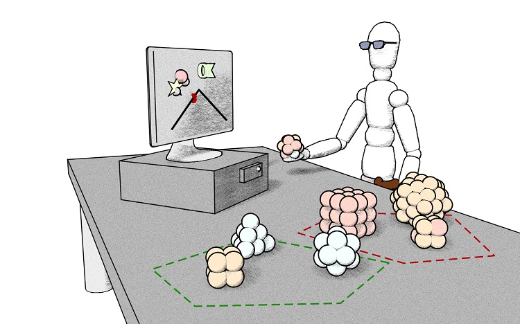

# Clustering (unsupervised machine learning)

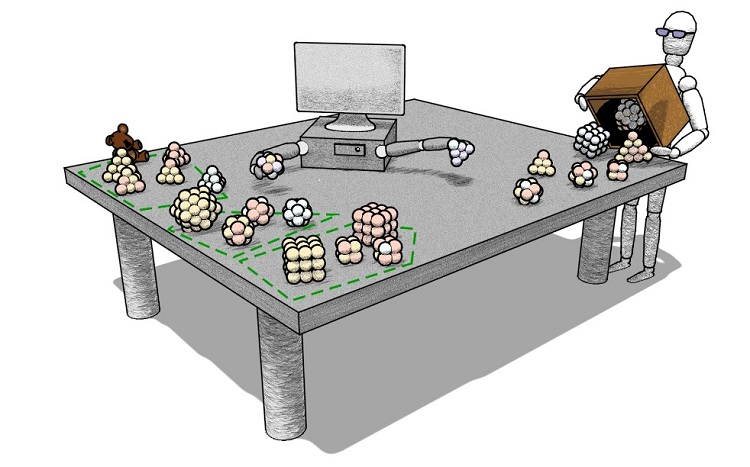

# Decision Tree (what the result looks like)

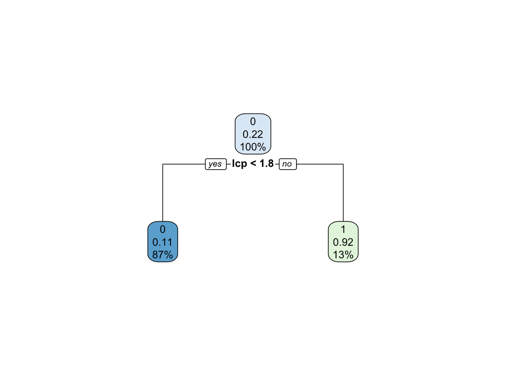

```r
library(ElemStatLearn)
library(rpart)
library(rpart.plot)
afit <- rpart(as.factor(svi) ~ . - train, data = prostate)
rpart.plot(afit)
```

- Target: build up a prediction rule to determine svi = 1 or 0
- Top node:
  - 0: predicted svi status if a new subject falls into this node
  - 0.22: probablity svi = 1
  - 100%: all 97 subjects
- Bottom left:
  - 0: predicted svi status if a new subject falls into this node
  - 0.11: probablity svi = 1
  - 87%: 84 subjects fall into this node
- Bottom right:
  - 1: predicted svi status if a new subject falls into this node
  - 0.92: probablity svi = 1
  - 13%: 13 subjects fall into this node

# Decision Tree

- Decision tree is a supervised learning algorithm (having a pre-defined labels).
- It works for both categorical and continuous input and output variables.
- In this technique, we split the population or sample into two or more homogeneous sets (or sub-populations) based on the best splitter.

# Motivating example

- Sample size n = 30
- Variables (features): three variables
  - Gender (Boy/ Girl)
  - Class (IX or X)
  - Height (5 to 6 ft)
- Outcome (labels): 15 out of these 30 play cricket in leisure time.

Purpose: predict whether a student will play cricket in his/her leisure time, based on his/her three variables.

# Decision tree

- Decision tree identifies the most significant variable and it’s value that gives best homogeneous sets of population.

Questions:

- What does the decision tree structure look like?
- How to define **homogeneous**?
- How to make a prediction for a new person?

# Decision tree structure

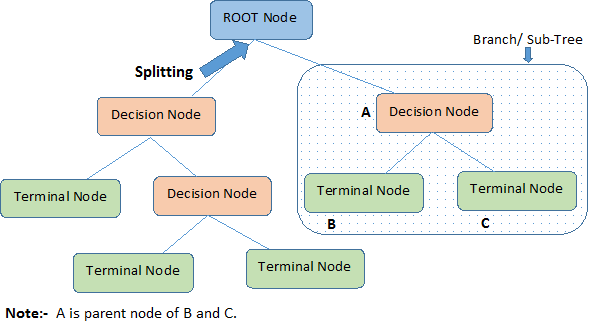

Terminology:

- **Root Node**: It represents entire population or sample and no split yet.
- **Splitting**: Dividing a node into two or more sub-nodes.
- **Decision Node**: When a sub-node splits into further sub-nodes, then it is called decision node.
- **Leaf/ Terminal Node**: Nodes do not split is called Leaf or Terminal node.
- **Pruning**: When we remove sub-nodes of a decision node, this process is called pruning. You can say opposite process of splitting.
- **Branch / Sub-Tree**: A sub section of entire tree is called branch or sub-tree.
- **Parent and Child Node**: A node, which is divided into sub-nodes is called parent node of sub-nodes where as sub-nodes are the child of parent node.

# How does a tree decide where to split?

Goodness of split (GOS) criteria - impurity

Details: - Selects the split and cutoff which result in most pure subset of nodes. - explores to split all available nodes. - explores to split all possible cutoffs for each node.

[figure not shown]

# Recommended measure of GOS (impurity)

- Gini Index
- Entropy
- Interpretation about impurity:
  - 0 indicates pure
  - large value indicates impure.

# Gini Index

Assume:

- outcome variable $Y$ is binary ($Y = 0$ or $Y = 1$).
- $t$ is a node

$$M_{Gini}(t) = 1 - P(Y = 0 | X \in t)^2 - P(Y = 1 | X \in t)^2$$

# Gini Index

- root:
  $$M_{Gini}(R) = 1 - 0.5^2 - 0.5^2 = 0.5$$
- Gender:Female:
  $$M_{Gini}(G:F) = 1 - 0.2^2 - 0.8^2 = 0.32$$
- Gender:Male:
  $$M_{Gini}(G:M) = 1 - 0.65^2 - 0.35^2 = 0.455$$
- Class:IX:
  $$M_{Gini}(C:4) = 1 - 0.43^2 - 0.57^2 = 0.4902$$
- Class:X:
  $$M_{Gini}(C:5) = 1 - 0.56^2 - 0.44^2 = 0.4928$$
- Height:5.5+:
  $$M_{Gini}(H:5.5+) = 1 - 0.56^2 - 0.44^2 = 0.4928$$
- Height:5.5-:
  $$M_{Gini}(H:5.5-) = 1 - 0.42^2 - 0.58^2 = 0.4872$$

# Goodness of split (GOS) criteria using Gini Index

Given an impurity function $M(t)$, the GOS criterion is to find the split $t_L$ and $t_R$ of note $t$ such that the impurity measure is maximally decreased:

$$\arg \max_{t_R, t_L} M(t) - [P(X\in t_L|X\in t) M(t_L) + P(X\in t_R|X\in t) M(t_R)]$$

- If split on Gender:
  $$M_{Gini}(R) - \frac{10}{30}M_{Gini}(G:F) - \frac{20}{30}M_{Gini}(G:M)
  = 0.5 - 10/30\times 0.32 - 20/30\times 0.455 = 0.09$$
- If split on Class:
  $$M_{Gini}(R) - \frac{14}{30}M_{Gini}(C:4) - \frac{16}{30}M_{Gini}(C:5)
  = 0.5 - 14/30\times 0.4902 - 16/30\times 0.4928 = 0.008$$
- If split on Height:5.5
  $$M_{Gini}(R) - \frac{12}{30}M_{Gini}(H:5.5-) - \frac{18}{30}M_{Gini}(H:5.5+)
  = 0.5 - 12/30*0.4872 - 18/30*0.4928 = 0.00944$$

Therefore, we will split based on Gender (maximized decrease).

- Why 5.5? Actually we need to search all possible height cutoffs to select the best cutoff.

# Entropy

Assume:

- outcome variable $Y$ is binary ($Y = 0$ or $Y = 1$).
- $t$ is a node

$$M_{entropy}(t) = - P(Y = 0 | X \in t)\log P(Y = 0 | X \in t)
- P(Y = 1 | X \in t)\log P(Y = 1 | X \in t)$$

# Entropy

- root:
  $$M_{entropy}(R) = -0.5 \times \log(0.5) -0.5 \times \log(0.5) = 0.6931472$$
- Gender:Female:
  $$M_{entropy}(G:F) = -0.2 \times \log(0.2) -0.8 \times \log(0.8) = 0.5004024$$
- Gender:Male:
  $$M_{entropy}(G:M) = -0.65 \times \log(0.65) -0.35 \times \log(0.35) = 0.6474466$$
- Class:IX:
  $$M_{entropy}(C:4) = -0.43 \times \log(0.43) -0.57 \times \log(0.57) = 0.6833149$$
- Class:X:
  $$M_{entropy}(C:5) = -0.56 \times \log(0.56) -0.44 \times \log(0.44) = 0.6859298$$
- Height:5.5+:
  $$M_{entropy}(H:5.5+) = -0.56 \times \log(0.56) -0.44 \times \log(0.44) = 0.6859298$$
- Height:5.5-:
  $$M_{entropy}(H:5.5-) = -0.42 \times \log(0.42) -0.58 \times \log(0.58) = 0.680292$$

# Goodness of split (GOS) criteria using entropy

Given an impurity function $M(t)$, the GOS criterion is to find the split $t_L$ and $t_R$ of note $t$ such that the impurity measure is maximally decreased:

$$\arg \max_{t_R, t_L} M(t) - [P(X\in t_L|X\in t) M(t_L) + P(X\in t_R|X\in t) M(t_R)]$$

- If split on Gender:
  $$M_{entropy}(R) - \frac{10}{30}M_{entropy}(G:F) - \frac{20}{30}M_{entropy}(G:M)
  = 0.6931472 - 10/30\times 0.5004024 - 20/30\times 0.6474466 = 0.09471533$$
- If split on Class:
  $$M_{entropy}(R) - \frac{14}{30}M_{entropy}(C:4) - \frac{16}{30}M_{entropy}(C:5)
  = 0.6931472 - 14/30\times 0.6833149 - 16/30\times 0.6859298 = 0.008437687$$
- If split on Height:5.5
  $$M_{entropy}(R) - \frac{12}{30}M_{entropy}(H:5.5-) - \frac{18}{30}M_{entropy}(H:5.5+)
  = 0.6931472 - 12/30 \times 0.680292 - 18/30\times 0.6859298 = 0.00947252$$

Therefore, we will split based on Gender (maximized decrease).

# Summary of impurity measurement

- Categorical outcome
  - Gini Index
  - Entropy
  - Chi-Square
- Continuous outcome
  - Reduction in Variance

Complexity for each split:

- $O(np)$
  - for each variable, search for all possible cutoffs (n).
  - Repeat this for all variables (p of them).

# Decision tree

How to make a prediction:

$$\hat{p}_{mk} = \frac{1}{N_m} \sum_{x_i \in t_m} \mathbb{I}(y_i = k)$$

E.g. if a new subject (G:Male, Class:X, H:5.8ft) falls into a terminal node, we just do a majority vote.

# Regression Trees vs Classification Trees

- Regression trees
  - dependent variable is continuous
  - predictive value at a terminal node: mean response of observation falling in that region
    $$\hat{c}_{m} = ave(y_i|x_i \in T_m)$$
- Classification trees
  - dependent variable is categorical
  - predictive value at a terminal node: mode of observations falling in that region

# Prostate cancer example

```r
library(ElemStatLearn)
library(rpart)
library(rpart.plot)
head(prostate)
```

```
##       lcavol  lweight age      lbph svi       lcp gleason pgg45       lpsa
## 1 -0.5798185 2.769459  50 -1.386294   0 -1.386294       6     0 -0.4307829
## 2 -0.9942523 3.319626  58 -1.386294   0 -1.386294       6     0 -0.1625189
## 3 -0.5108256 2.691243  74 -1.386294   0 -1.386294       7    20 -0.1625189
## 4 -1.2039728 3.282789  58 -1.386294   0 -1.386294       6     0 -0.1625189
## 5  0.7514161 3.432373  62 -1.386294   0 -1.386294       6     0  0.3715636
## 6 -1.0498221 3.228826  50 -1.386294   0 -1.386294       6     0  0.7654678
##   train
## 1  TRUE
## 2  TRUE
## 3  TRUE
## 4  TRUE
## 5  TRUE
## 6  TRUE
```

# Training set and testing set

For supervised machine learning, usually we split the data into the training set and the testing set.

- Training set: to build the classifier (build the decision rule in the CART model)
- Testing set: evaluate the performance of the classifier from the training set.

# Apply cart

```r
prostate_train <- subset(prostate, subset = train==TRUE)
prostate_test <- subset(prostate, subset = train==FALSE)

afit <- rpart(as.factor(svi) ~ . - train, data = prostate_train) ## svi as binary outcome
#afit <- rpart(svi ~ . - train, data = prostate_train) ## svi as continuous outcome
afit
```

```
## n= 67
##
## node), split, n, loss, yval, (yprob)
##       * denotes terminal node
##
## 1) root 67 15 0 (0.77611940 0.22388060)
##   2) lcavol< 2.523279 52  3 0 (0.94230769 0.05769231) *
##   3) lcavol>=2.523279 15  3 1 (0.20000000 0.80000000) *
```

# Visualize cart result

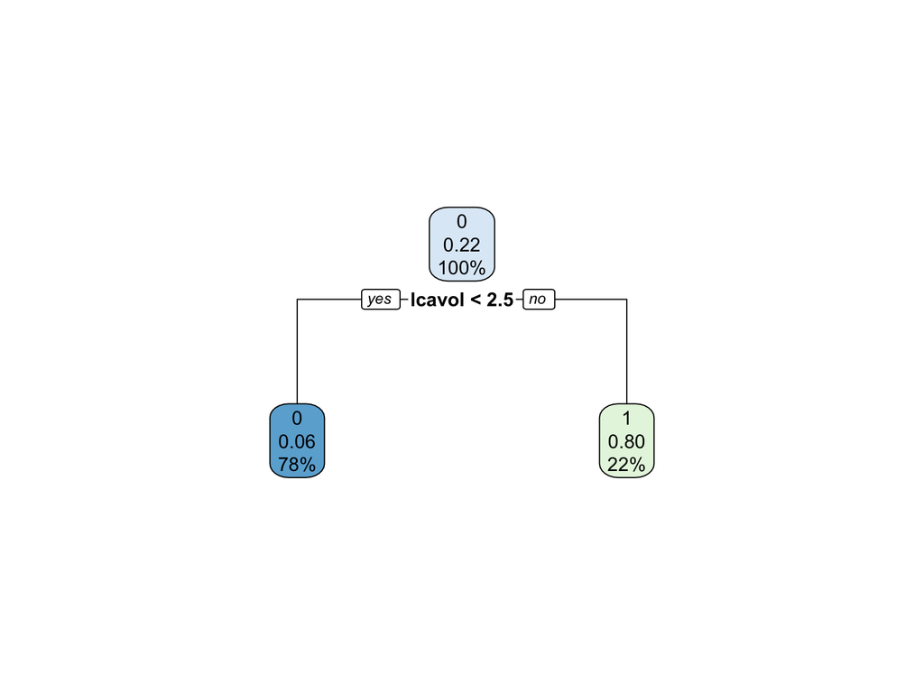

```r
rpart.plot(afit)
```

- Top node:
  - 0: predicted svi status if a new subject falls into this node
  - 0.22: probablity svi = 1
  - 100%: all 67 subjects
- Bottom left:
  - 0: predicted svi status if a new subject falls into this node
  - 0.06: probablity svi = 1
  - 78%: 52 subjects fall into this node
- Bottom right:
  - 1: predicted svi status if a new subject falls into this node
  - 0.80: probablity svi = 1
  - 22%: 15 subjects fall into this node

# predicting the testing dataset using CART subject

```r
predProb_cart <- predict(object = afit, newdata = prostate_test)
head(predProb_cart)
```

```
##            0          1
## 7  0.9423077 0.05769231
## 9  0.9423077 0.05769231
## 10 0.9423077 0.05769231
## 15 0.9423077 0.05769231
## 22 0.9423077 0.05769231
## 25 0.9423077 0.05769231
```

```r
atable <- table(predictLabel = predProb_cart[,"1"]>0.5, trueLabel = prostate_test$svi)
atable
```

```
##             trueLabel
## predictLabel  0  1
##        FALSE 21  4
##        TRUE   3  2
```

```r
## accuracy
sum(diag(atable)) / sum(atable)
```

```
## [1] 0.7666667
```

# Overfitting problem

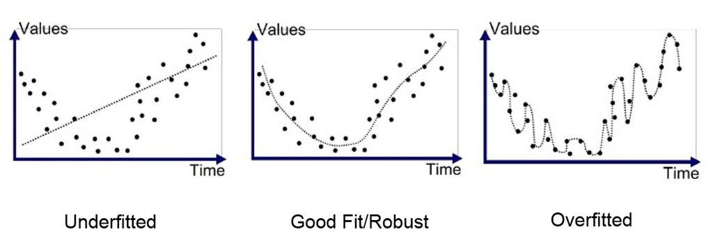

# Pruning the tree (to reduce overfitting)

# Titanic example (Will be on HW)

```r
library(titanic)
dim(titanic_train)
```

```
## [1] 891  12
```

```r
head(titanic_train)
```

```
##   PassengerId Survived Pclass
## 1           1        0      3
## 2           2        1      1
## 3           3        1      3
## 4           4        1      1
## 5           5        0      3
## 6           6        0      3
##                                                  Name    Sex Age SibSp Parch
## 1                             Braund, Mr. Owen Harris   male  22     1     0
## 2 Cumings, Mrs. John Bradley (Florence Briggs Thayer) female  38     1     0
## 3                              Heikkinen, Miss. Laina female  26     0     0
## 4        Futrelle, Mrs. Jacques Heath (Lily May Peel) female  35     1     0
## 5                            Allen, Mr. William Henry   male  35     0     0
## 6                                    Moran, Mr. James   male  NA     0     0
##             Ticket    Fare Cabin Embarked
## 1        A/5 21171  7.2500              S
## 2         PC 17599 71.2833   C85        C
## 3 STON/O2. 3101282  7.9250              S
## 4           113803 53.1000  C123        S
## 5           373450  8.0500              S
## 6           330877  8.4583              Q
```

# Bagging

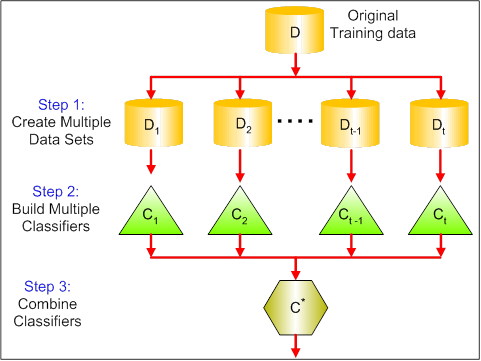

# Bagging

1. Create Multiple DataSets:
   - Sampling with replacement on the original data
   - Taking row and column fractions less than 1 helps in making robust models, less prone to overfitting
2. Build Multiple Classifiers:
   - Classifiers are built on each data set.
3. Combine Classifiers:
   - The predictions of all the classifiers are combined using a mean, median or mode value depending on the problem at hand.
   - The combined values are generally more robust than a single model.

# Random forest

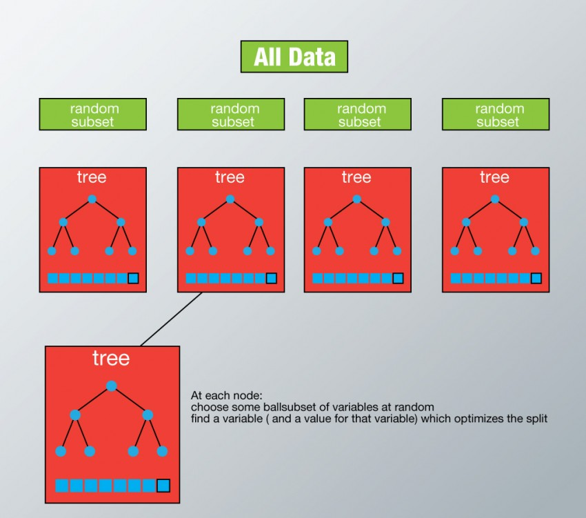

# Random forest algorithm

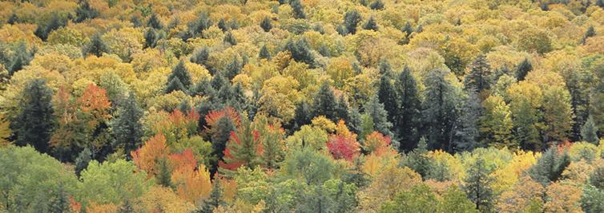

Assume number of cases in the training set is N, and number of features is M.

1. Repeat the following procedures B = 500 times (each time is a CART algorithm):
   1. Sample N cases with replacement.
   2. Sample m<M features without replacement.
   3. Apply the CART algorithm without pruning.
2. Predict new data by aggregating the predictions of the B trees (i.e., majority votes for classification, average for regression).

# Random forest

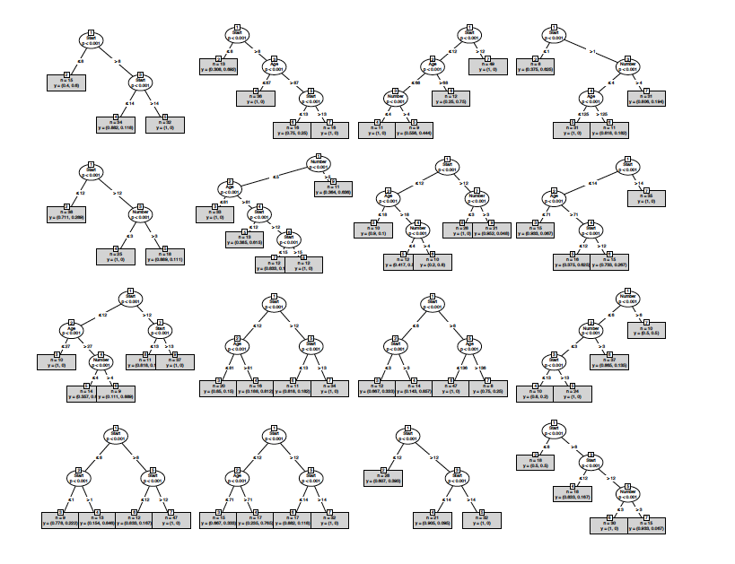

# Random Forest on prostate cancer example

```r
library("randomForest")
prostate_train <- subset(prostate, subset = train==TRUE)
prostate_test <- subset(prostate, subset = train==FALSE)

rffit <- randomForest(as.factor(svi) ~ . - train, data = prostate_train)
rffit
```

```
##
## Call:
##  randomForest(formula = as.factor(svi) ~ . - train, data = prostate_train)
##                Type of random forest: classification
##                      Number of trees: 500
## No. of variables tried at each split: 2
##
##         OOB estimate of  error rate: 13.43%
## Confusion matrix:
##    0  1 class.error
## 0 48  4  0.07692308
## 1  5 10  0.33333333
```

# Random Forest on prostate prediction

```r
pred_rf <- predict(rffit, prostate_test)

ctable <- table(pred_rf, trueLabel = prostate_test$svi)
ctable
```

```
##        trueLabel
## pred_rf  0  1
##       0 22  4
##       1  2  2
```

```r
## accuracy
sum(diag(ctable)) / sum(ctable)
```

```
## [1] 0.8
```

# Random Forest importance score

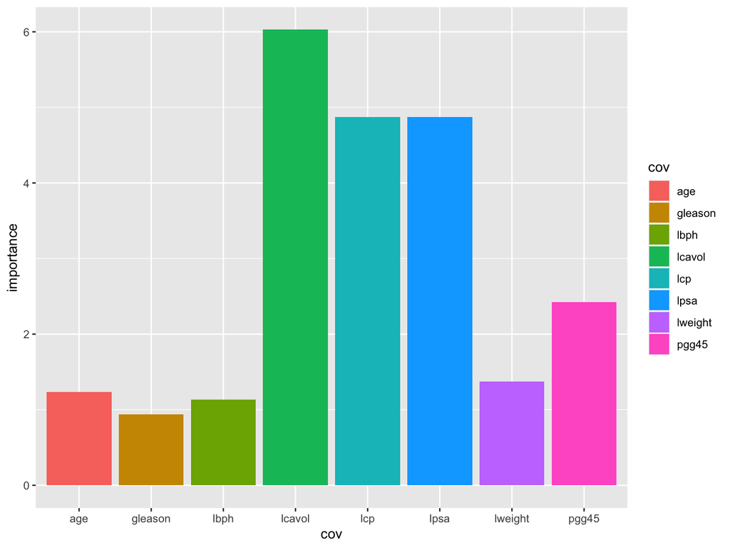

```r
library(ggplot2)
imp <- importance(rffit)
impData <- data.frame(cov = rownames(imp), importance=imp[,1])

ggplot(impData) + aes(x=cov, y=importance, fill=cov) + geom_bar(stat="identity")
```

# How to calculate Random Forest importance score

- Within each tree $t$,
  - $\hat{y}_i^{(t)}$: predicted class before permuting
  - $\hat{y}_{i,\pi_j}^{(t)}$: predicted class after permuting $x_j$
    $$VI^{(t)}(x_j) = \frac{1}{|n^{(t)}|} \sum_{i \in n^{(t)}} I(y_i = \hat{y}_i^{(t)}) -
    \frac{1}{|n^{(t)}|} \sum_{i \in n^{(t)}} I(y_i = \hat{y}_{i,\pi_j}^{(t)})$$
- Raw importance:
  $$VI(x_j) = \frac{\sum_{t=1}^B VI^{(t)}(x_j)}{B}$$
- Scaled improtance: importance() funciton in R:
  $$z_j = \frac{VI(x_j)}{\hat{\sigma}/\sqrt{B}}$$

# Outline for cross validation

- cross validation to evaluate machine learning accuracy
  - holdout method
  - k-fold cross validation
  - leave one out cross validation
- cross validation to select tuning parameters

# Holdout method to evaluate machine learning accuracy

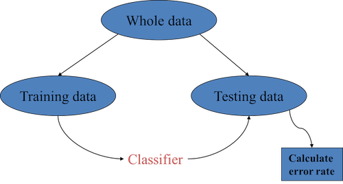

- Pros: easy to implement
- Cons: its evaluation may have a high variance.
  - depend heavily on which data points in the training set and which in the test set

# Holdout method example

```r
library(ElemStatLearn)
library(randomForest)

prostate0 <- prostate
prostate0$svi <- as.factor(prostate0$svi)
trainLabel <- prostate$train
prostate0$train <- NULL

prostate_train <- subset(prostate0, trainLabel)
prostate_test <- subset(prostate0, !trainLabel)

rfFit <- randomForest(svi ~ ., data=prostate_train)
rfFit
```

```
##
## Call:
##  randomForest(formula = svi ~ ., data = prostate_train)
##                Type of random forest: classification
##                      Number of trees: 500
## No. of variables tried at each split: 2
##
##         OOB estimate of  error rate: 14.93%
## Confusion matrix:
##    0 1 class.error
## 0 49 3  0.05769231
## 1  7 8  0.46666667
```

```r
rfPred <- predict(rfFit, prostate_test)
rfTable <- table(rfPred, truth=prostate_test$svi)
rfTable
```

```
##       truth
## rfPred  0  1
##      0 22  4
##      1  2  2
```

```r
1 - sum(diag(rfTable))/sum(rfTable) ## error rate
```

```
## [1] 0.2
```

# k-fold cross validation

- Only split the data into two parts may result in high variance.
- Another commonly used approach is to split the data into $K$ folds.
- Normally $K = 5$ or $K = 10$ are recommended to balance the bias and variance.

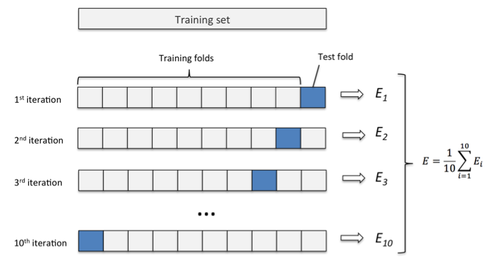

Algorithm:

- Split the original dataset $D$ into $K$ folds, and obtain $D_1, \ldots, D_k,\ldots, D_K$ such that $D_1, \ldots, D_K$ are disjoint; $|D_k|$ (size of $D_k$) is roughly the same for different $k$ and $\sum_k |D_k| = |D|$.
- For each iteration $k = 1, \ldots, K$, use the $D_k$ as the testing dataset and $D_{-k} = D - D_k$ as the training dataset. Build the classifier $f^k$ based on $D_{-k}$. Then predict $D_k$ and obtain the prediction error rate $E_k$
- Use $E = \frac{1}{K} \sum_k E_k$ as the final prediction error rate.

# k-fold cross validation example

```r
#Create K = 5 equally size folds

K <- 5
folds <- cut(seq(1,nrow(prostate0)),breaks=5,labels=FALSE)

EKs <- numeric(K)

for(k in 1:K){
  atrain <- subset(prostate0, folds != k)
  atest <- subset(prostate0, folds == k)

  krfFit <- randomForest(svi ~ ., data=atrain)
  krfPred <- predict(krfFit, atest)
  krfTable <- table(krfPred, truth=atest$svi)

  EKs[k] <- 1 - sum(diag(krfTable))/sum(krfTable)
}

EKs
```

```
## [1] 0.00000000 0.05263158 0.00000000 0.26315789 0.40000000
```

```r
mean(EKs)
```

```
## [1] 0.1431579
```

# Leave one out cross validation

For K-fold cross validation

- $K = n$, leave one out cross validation
  - Each time, only use one sample as the testing sample and the rest of all sample as the training data.
  - Iterate total $n$ times.

# leave one out cross validation example

```r
n <- nrow(prostate0)

EKs <- numeric(n)

for(k in 1:n){
  #cat("leaving the",k,"sample out!","\n")
  atrain <- prostate0[-k,]
  atest <- prostate0[k,]

  krfFit <- randomForest(svi ~ ., data=atrain)
  krfPred <- predict(krfFit, atest)
  krfTable <- table(krfPred, truth=atest$svi)

  EKs[k] <- 1 - sum(diag(krfTable))/sum(krfTable)
}

EKs
```

```
##  [1] 0 0 0 0 0 0 0 0 0 0 0 0 0 0 0 0 0 0 0 0 0 0 0 0 0 0 0 0 0 0 0 0 0 0 0 0 0 0
## [39] 0 0 0 0 0 0 0 0 0 0 0 0 0 0 0 0 0 0 0 0 0 0 0 1 1 1 0 0 0 0 0 0 1 0 1 1 0 0
## [77] 0 0 0 1 0 1 1 1 0 0 0 1 0 1 0 1 0 0 0 0 0
```

```r
mean(EKs)
```

```
## [1] 0.1340206
```

# Important note for cross validation

- the classifier should only build on the training data.
- the classifier should not use the information of the testing data.

# Choosing tuning parameters

Some machine learning classifiers contain tuning parameters

- CART: pruning criteria.
- K-nearest-neighbors (KNN): K (will be introduced shortly)
- Lasso: regularization penalty $\lambda$.

The tuning parameter is crucial since it controls the amount of regularization (model complexity).

# Tuning parameter selection

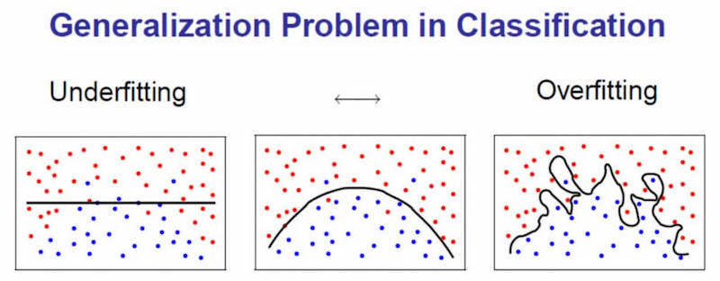

# Lasso problem

$$\hat{\beta}^{lasso} = \frac{1}{2}\arg\min_{\beta \in \mathbb{R}^P} \|y - X\beta\|_2^2 + \lambda \|\beta\|_1$$

```r
library(lars)
```

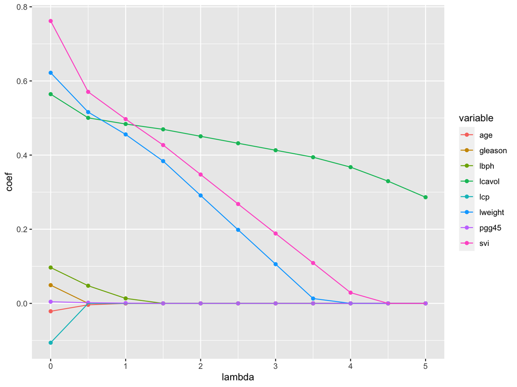

```r
library(ggplot2)
options(stringsAsFactors=F)
x <- as.matrix(prostate[,1:8])
y <- prostate[,9]
lassoFit <- lars(x, y) ## lar for least angle regression

lambdas <- seq(0,5,0.5)
coefLassoFit <- coef(lassoFit, s=lambdas, mode="lambda")
adataFrame <- NULL
for(i in 1:ncol(coefLassoFit)){
  acoef <- colnames(coefLassoFit)[i]
  adataFrame0 <- data.frame(lambda=lambdas, coef = coefLassoFit[,i], variable=acoef)
  adataFrame <- rbind(adataFrame, adataFrame0)
}

ggplot(adataFrame) + aes(x=lambda, y=coef, col=variable) +
  geom_point() +
  geom_path()
```

# How to select the best tuning parameter

- Use cross validation.
- We should choose the tuning parameter such that the cross validation error is minimized.

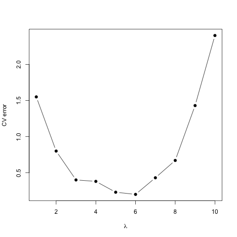

# Tuning parameter selection algorithm

- Split the original dataset $D$ into $K$ folds, and obtain $D_1, \ldots, D_k,\ldots, D_K$ such that $D_1, \ldots, D_K$ are disjoint; $|D_k|$ (size of $D_k$) is roughly the same for different $k$ and $\sum_k |D_k| = |D|$.
- pre-specify a range of tuning parameters $\lambda_1, \ldots, \lambda_B$
- For each iteration $k = 1, \ldots, K$, use the $D_k$ as the testing dataset and $D_{-k} = D - D_k$ as the training dataset. Build the classifier $f^k_{\lambda_b}$ based on $D_{-k}$ and tuning parameter $\lambda_b$, $(1 \le b \le B)$. Then predict $D_k$ and obtain the
  - mean squared error (MSE) or root mean squared error (rMSE) $e_k(\lambda_b)$ for continuous outcome.
  - classification error rate for categorical outcome variable.
- Use $e(\lambda_b) = \frac{1}{K} \sum_k e_k(\lambda_b)$ as the average (MSE, rMSE or classification error rate) for tuning parameter $(\lambda_b)$.
- Choose the tuning parameter $\hat{\lambda} = \arg \min_{\lambda\in (\lambda_1, \ldots, \lambda_B)} e(\lambda)$

Choose the tuning parameter $\hat{\lambda} = \arg \min_{\lambda\in (\lambda_1, \ldots, \lambda_B)} e(\lambda)$

- Continuous outcome MSE:
  $$e(\lambda) = \frac{1}{K} \sum_{k=1}^K \sum_{i \in D_k} (y_i - \hat{f}_\lambda^{-k}(x_i))^2$$
- Continuous outcome rMSE:
  $$e(\lambda) = \frac{1}{K} \sum_{k=1}^K \sqrt{\sum_{i \in D_k} (y_i - \hat{f}_\lambda^{-k}(x_i))^2}$$
- Categorical outcome variable classification error rate:
  $$e(\lambda) = \frac{1}{K} \sum_{k=1}^K \frac{1}{|D_k|}\sum_{i \in D_k} \mathbb{I}(y_i \ne \hat{f}_\lambda^{-k}(x_i))$$

# Implement tuning parameter selection for lasso problem

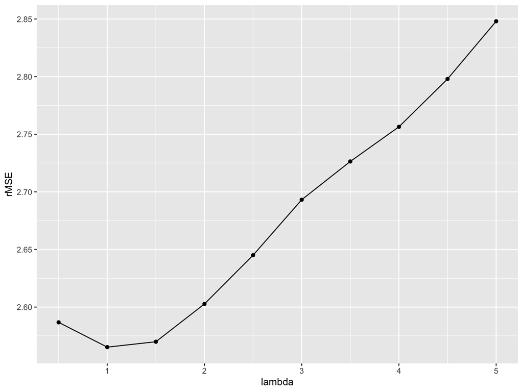

```r
K <- 10
folds <- cut(seq(1,nrow(prostate)),breaks=K,labels=FALSE)
lambdas <- seq(0.5,5,0.5)

rMSEs <- matrix(NA,nrow=length(lambdas),ncol=K)
rownames(rMSEs) <- lambdas
colnames(rMSEs) <- 1:K

for(k in 1:K){
  atrainx <- as.matrix(prostate[!folds==k,1:8])
  atestx <- as.matrix(prostate[folds==k,1:8])

  atrainy <- prostate[!folds==k,9]
  atesty <- prostate[folds==k,9]

  klassoFit <- lars(atrainx, atrainy) ## lar for least angle regression

  predictValue <- predict.lars(klassoFit, atestx, s=lambdas, type="fit",  mode="lambda")
  rMSE <- apply(predictValue$fit,2, function(x) sqrt(sum((x - atesty)^2))) ## square root MSE

  rMSEs[,k] <- rMSE
}

rMSEdataFrame <- data.frame(lambda=lambdas, rMSE = rowMeans(rMSEs))
ggplot(rMSEdataFrame) + aes(x=lambda, y = rMSE) + geom_point() + geom_path()
```

# Common mistake about tuning parameter selection in machine learning

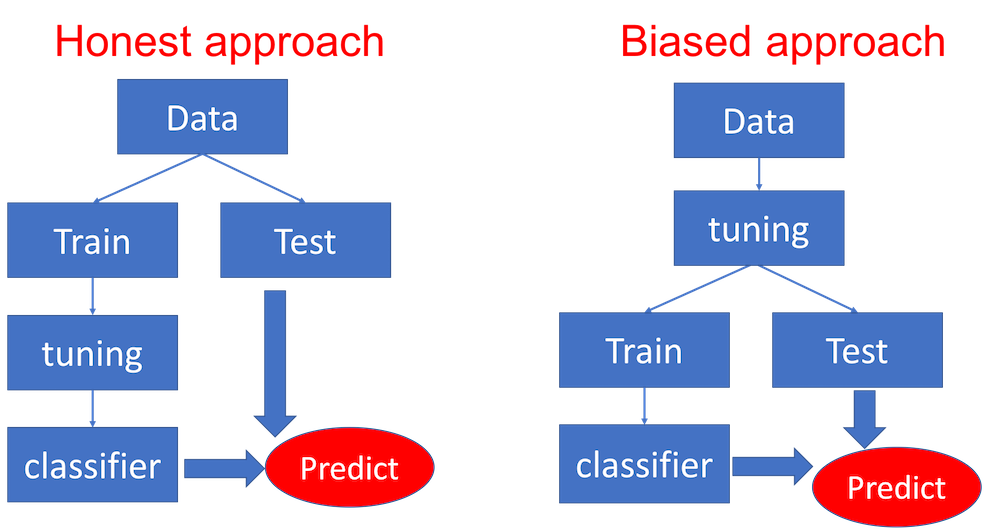

# Combine selecting tuning parameters and evaluating prediction accuracy

1. Split the data into training set and testing set.
2. In training set, use cross validation to determine the best tuning parameter.
3. Use the best tuning parameter and the entire training set to build a classifier.
4. Evaluation:
   - Predict the testing set
   - Report the accuracy.

For **Step 1**, can we also use cross validation?

# Nested Cross validation

1. Use K-folder cross validation (outer) to split the original data into training set and testing set.
2. For $k^{th}$ fold training set, use cross validation (inner) to determine the best tuning parameter of the $k^{th}$ fold.
3. Use the best tuning parameter of the $k^{th}$ fold and the $k^{th}$ fold training set to build a classifier.
4. Predict the $k^{th}$ fold testing set and report the accuracy.
5. Evaluation:
   - Report the average accuracy from outer K-folder cross validation..

# References

- https://www.analyticsvidhya.com/blog/2016/04/complete-tutorial-tree-based-modeling-scratch-in-python/
- https://www.statistik.uni-dortmund.de/useR-2008/slides/Strobl+Zeileis.pdf
- Element of stat learning https://web.stanford.edu/~hastie/ElemStatLearn/